## **Julia Creek dunnart**

### Blamed on cats

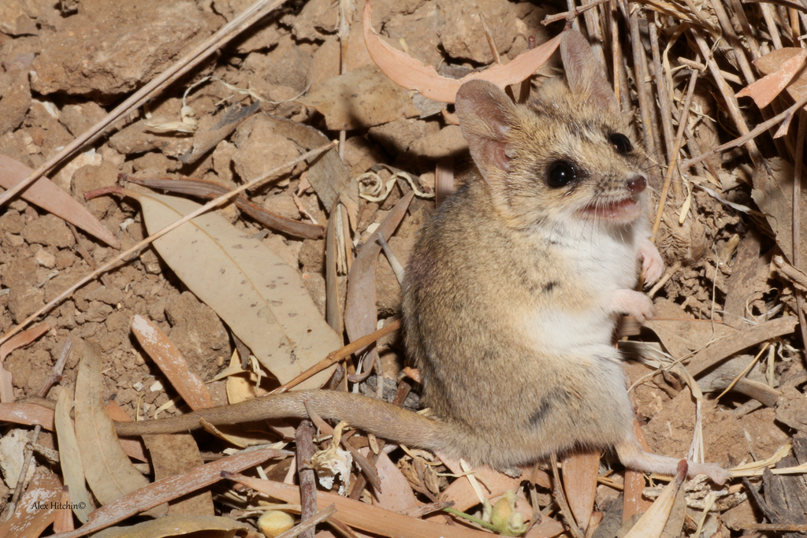

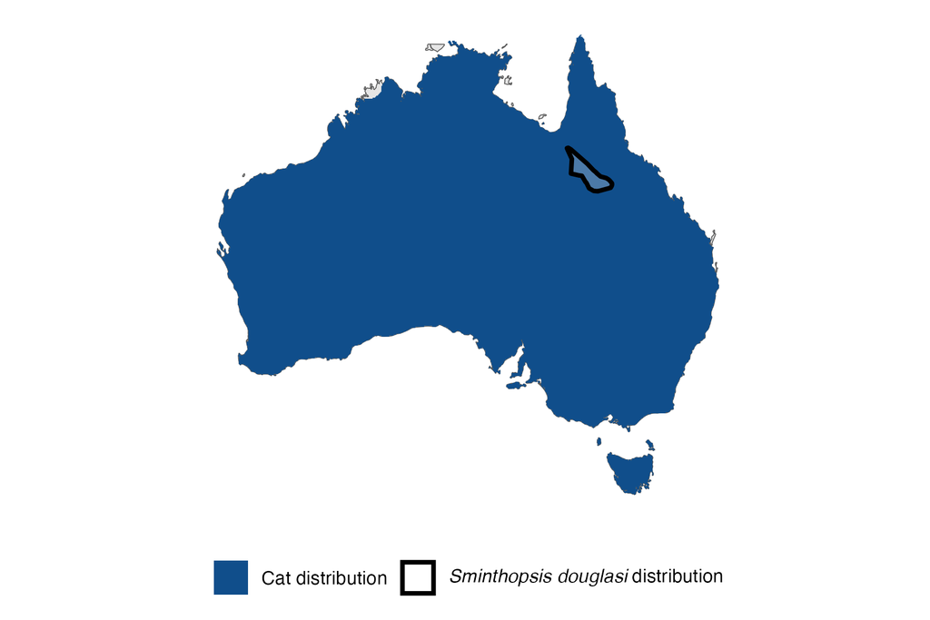

IUCN status: **Near Threatened**

EPBC Predator Threat Rating: **Very high**

IUCN claim: *“Exotic predators (especially cats and foxes)”*

### Studies in support

Cats hunt Julia Creek dunnarts (Kutt 2003; Kutt 2011; Kutt 2012; Mifsud & Woolley 2012).

### Studies not in support

Cats do not select for Smithopsis spp. (Kutt 2012).

### Is the threat claim evidence-based?

No studies were found linking cats to Julia Creek dunnart population trends.

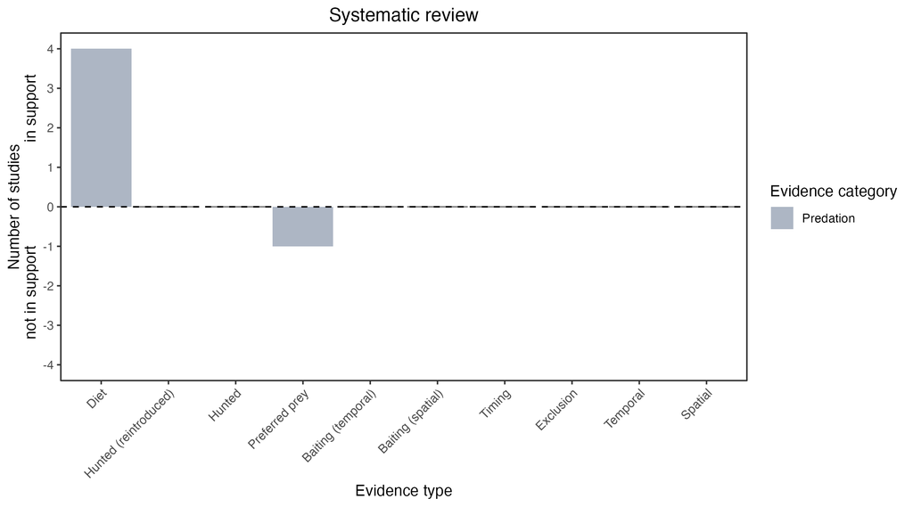

**Evidence linking *Sminthopsis douglasi* to cats.** Systematic review of evidence for an association between *Sminthopsis douglasi* and cats. Positive studies are in support of the hypothesis that *cats* contribute to the decline of Sminthopsis douglasi, negative studies are not in support. Predation studies include studies documenting hunting or scavenging; baiting studies are associations between poison baiting and threatened mammal abundance where information on predator abundance is not provided; population studies are associations between threatened mammal and predator abundance. Gold borders indicate studies that meet qualities of scientific rigour. See methods section in Wallach and Lundgren 2025 for details on evidence categories.

### References

EPBC. (2015) Threat Abatement Plan for Predation by Feral Cats. Environment Protection and Biodiversity Conservation Act 1999, Department of Environment, Government of Australia. (Table A1).

IUCN Red List. https://www.iucnredlist.org/ Accessed June 2023

Kutt, A.S., 2003. New records of the Julia Creek Dunnart Sminthopsis douglasi in central-north Queensland. Australian Zoologist, 32(2), pp.257-260.

Kutt, A.S., 2011. The diet of the feral cat (Felis catus) in north-eastern Australia. Acta Theriologica, 56(2), pp.157-169.

Kutt, A.S., 2012. Feral cat (Felis catus) prey size and selectivity in north‐eastern A ustralia: implications for mammal conservation. Journal of Zoology, 287(4), pp.292-300.

Mifsud, G. and Woolley, P.A., 2012. Predation of the Julia Creek dunnart (Sminthopsis douglasi) and other native fauna by cats and foxes on Mitchell grass downs in Queensland. Australian Mammalogy, 34(2), pp.188-195.

Wallach A.D., Lundgren E.J. (2025) Review of evidence that foxes and cats cause extinctions of Australia’s endemic mammals. BioScience. DOI: 10.1093/biosci/biaf046